# BANA 7047 – Individual Case III

Prof. Yan Yu

16/04/2020

**Last Name:** Joshi

**First Name:** Sankirna

**M#:** M13263600

Please use this as your cover page and follow the required format below. Points will be deducted otherwise.

## European Employment Data – Clustering

The data are the percentage employed in different industries in Europe countries during 1979. The purpose of examining this data is to get insight into patterns of employment (if any) amongst European countries in 1970s.

Variable Names:  
- Country: Name of country  
- Agr: Percentage employed in agriculture  
- Min: Percentage employed in mining  
- Man: Percentage employed in manufacturing  
- PS: Percentage employed in power supply industries  
- Con: Percentage employed in construction  
- SI: Percentage employed in service industries  
- Fin: Percentage employed in finance  
- SPS: Percentage employed in social and personal services  
- TC: Percentage employed in transport and communications

```r
library(ggplot2)
library(dplyr)
library(tidyverse)  # data manipulation
library(cluster)    # clustering algorithms
library(factoextra) # clustering algorithms & visualization
library(dendextend) # for comparing two dendrograms
library(corrplot)
library(data.table)
library(arules)
library(arulesViz)
```

```r
employment <- read.csv("europeanJobs.txt", sep="\t")

row.names(employment)<-employment$Country
employment <- employment[,-1]

head(employment)
```

```
##           Agr Min  Man  PS  Con   SI Fin  SPS  TC
## Belgium   3.3 0.9 27.6 0.9  8.2 19.1 6.2 26.6 7.2
## Denmark   9.2 0.1 21.8 0.6  8.3 14.6 6.5 32.2 7.1
## France   10.8 0.8 27.5 0.9  8.9 16.8 6.0 22.6 5.7
## WGermany  6.7 1.3 35.8 0.9  7.3 14.4 5.0 22.3 6.1
## Ireland  23.2 1.0 20.7 1.3  7.5 16.8 2.8 20.8 6.1
## Italy    15.9 0.6 27.6 0.5 10.0 18.1 1.6 20.1 5.7
```

```r
summary(employment)
```

```
##       Agr             Min             Man              PS
##  Min.   : 2.70   Min.   :0.100   Min.   : 7.90   Min.   :0.1000
##  1st Qu.: 7.70   1st Qu.:0.525   1st Qu.:23.00   1st Qu.:0.6000
##  Median :14.45   Median :0.950   Median :27.55   Median :0.8500
##  Mean   :19.13   Mean   :1.254   Mean   :27.01   Mean   :0.9077
##  3rd Qu.:23.68   3rd Qu.:1.800   3rd Qu.:30.20   3rd Qu.:1.1750
##  Max.   :66.80   Max.   :3.100   Max.   :41.20   Max.   :1.9000
##       Con               SI             Fin              SPS
##  Min.   : 2.800   Min.   : 5.20   Min.   : 0.500   Min.   : 5.30
##  1st Qu.: 7.525   1st Qu.: 9.25   1st Qu.: 1.225   1st Qu.:16.25
##  Median : 8.350   Median :14.40   Median : 4.650   Median :19.65
##  Mean   : 8.165   Mean   :12.96   Mean   : 4.000   Mean   :20.02
##  3rd Qu.: 8.975   3rd Qu.:16.88   3rd Qu.: 5.925   3rd Qu.:24.12
##  Max.   :11.500   Max.   :19.10   Max.   :11.300   Max.   :32.40
##        TC
##  Min.   :3.200
##  1st Qu.:5.700
##  Median :6.700
##  Mean   :6.546
##  3rd Qu.:7.075
##  Max.   :9.400
```

```r
employment <- scale(employment)
```

### Distance Matrix

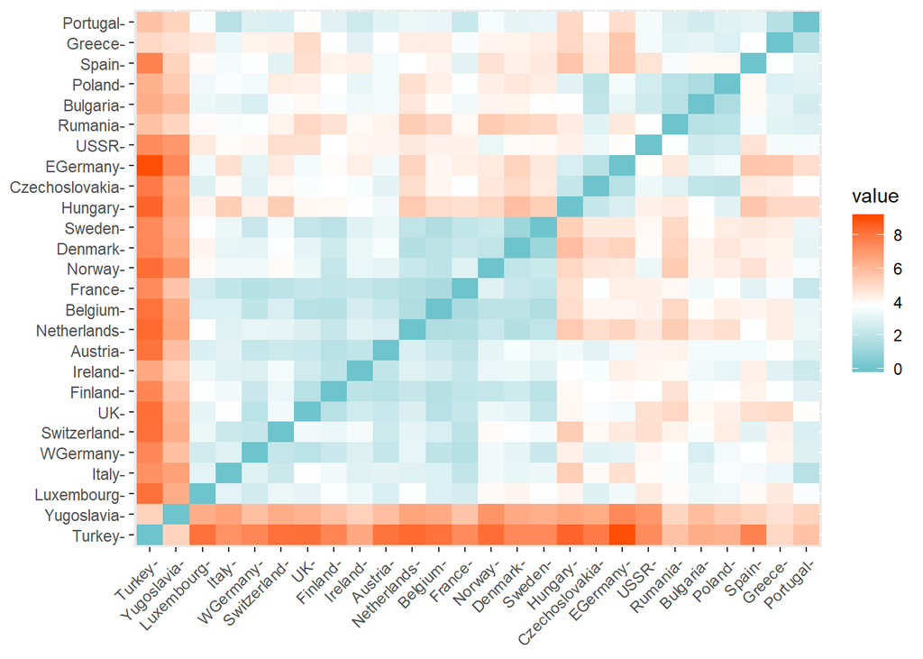

```r
distance <- get_dist(employment)
fviz_dist(distance, gradient = list(low = "#00AFBB", mid = "white", high = "#FC4E07"))
```

### K-Means Clustering

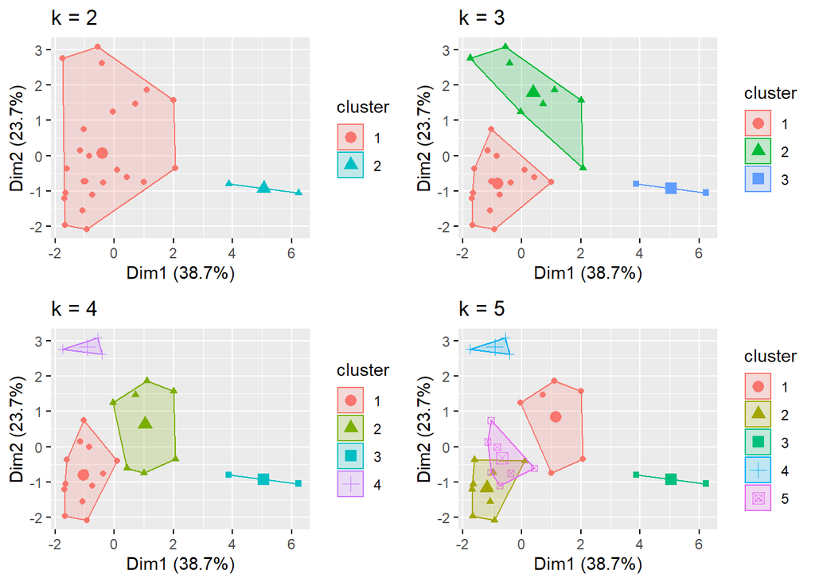

```r
k2 <- kmeans(employment, centers = 2, nstart = 25)
k3 <- kmeans(employment, centers = 3, nstart = 25)
k4 <- kmeans(employment, centers = 4, nstart = 25)
k5 <- kmeans(employment, centers = 5, nstart = 25)

# plots to compare
p1 <- fviz_cluster(k2, geom = "point",  data = employment) + ggtitle("k = 2")
p2 <- fviz_cluster(k3, geom = "point",  data = employment) + ggtitle("k = 3")
p3 <- fviz_cluster(k4, geom = "point",  data = employment) + ggtitle("k = 4")
p4 <- fviz_cluster(k5, geom = "point",  data = employment) + ggtitle("k = 5")

library(gridExtra)
grid.arrange(p1, p2, p3, p4, nrow = 2)
```

### Optimum number of clusters

Using the silhouette method, we can see the highest performing number of clusters

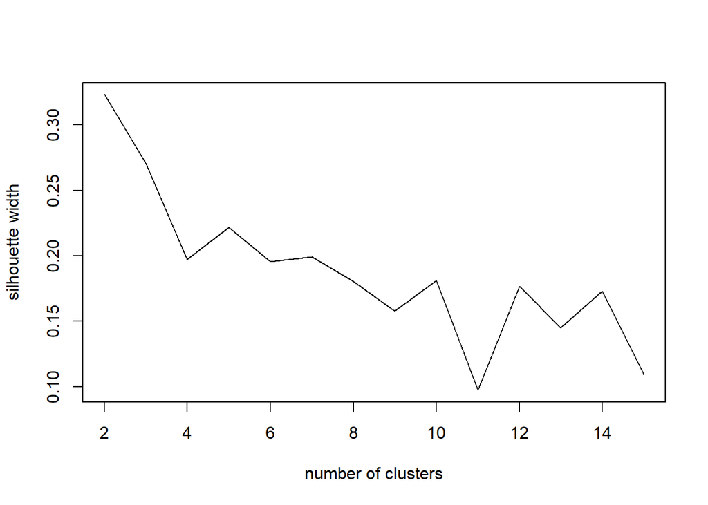

```r
library(fpc)
result = matrix(nrow = 14, ncol = 3)
d = dist(employment, method = "euclidean")
for (i in 2:15){
  cluster_result = kmeans(employment, i)
  clusterstat=cluster.stats(d, cluster_result$cluster)
  result[i-1,1]=i
  result[i-1,2]=clusterstat$avg.silwidth
  result[i-1,3]=clusterstat$dunn
}

plot(result[,c(1,2)], type="l", ylab = 'silhouette width', xlab = 'number of clusters')
```

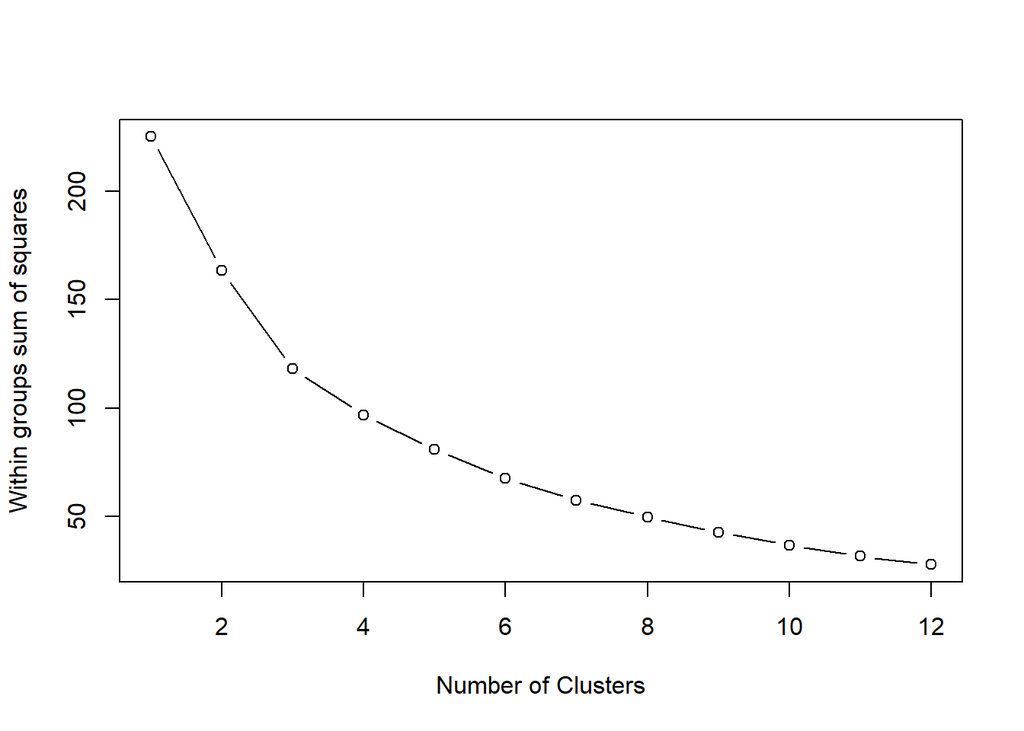

```r
# within cluster sum of squares
wss <- c()

for (i in 1:12)
  {
    # calculating total wss for each cluster size with 25 random iterations for each
    wss[i] <- sum(kmeans(employment, centers=i, nstart = 25)$withinss)
}

# plotting wss vs number of clusters
plot(1:12, wss, type="b", xlab="Number of Clusters",ylab="Within groups sum of squares")
```

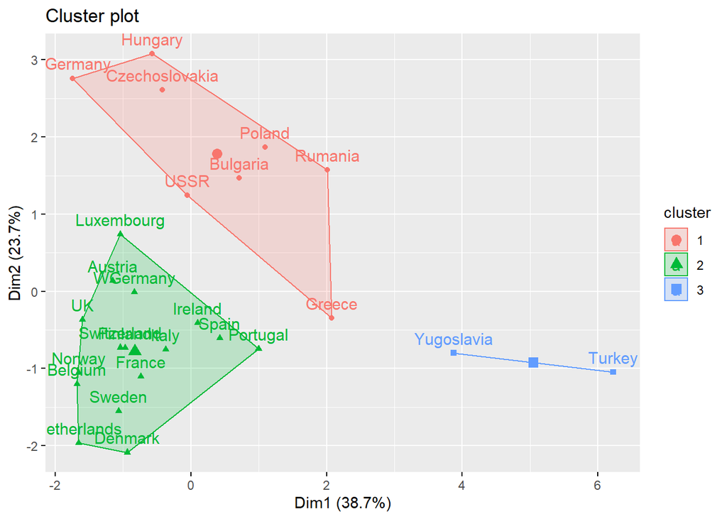

```r
set.seed(13263600)
final <- kmeans(employment, 3, nstart = 25)
fviz_cluster(final, data = employment)
```

### Interpretation:

It looks like a cluster of developed, developing, and under-developed European Nations. - Cluster 1: Developing - Cluster 2: Developed - Cluster 3: Under-Developed

### Hierarchical Clustering

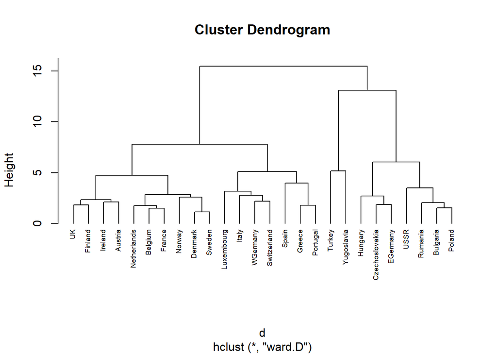

```r
# Hierarchical clustering using Complete Linkage
hc1 <- hclust(d, method = "ward.D" )
# Plot the obtained dendrogram
plot(hc1, cex = 0.6, hang = -1)
```

## Cincinnati Zoo

### Association Rule Mining

A Data Mining approach to understanding Cincinnati Zoo Customer Behavior.

### Background

About Cincinnati Zoo:

- Cincinnati Zoo was founded in 1873. Officially opened in 1875. Second oldest in the Nation after Pennsylvania Zoo.
- Zoo houses over 300 animal and over 3,000 plant species.
- Reptile house is the oldest Zoo building in the country, dating from 1875.
- Zoo serves over a million visitors each year.

```r
TransFood <- read.csv('https://xiaoruizhu.github.io/Data-Mining-R/data/food_4_association.csv')
TransFood <- TransFood[, -1]
# Find out elements that are not equal to 0 or 1 and change them to 1.
Others <- which(!(as.matrix(TransFood) ==1 | as.matrix(TransFood) ==0), arr.ind=T )
TransFood[Others] <- 1
TransFood <- as(as.matrix(TransFood), "transactions")
```

```r
summary(TransFood)
```

```
## transactions as itemMatrix in sparse format with
##  19076 rows (elements/itemsets/transactions) and
##  118 columns (items) and a density of 0.02230729
##
## most frequent items:
##   Bottled.WaterFood Slice.of.CheeseFood    Medium.DrinkFood
##                3166                3072                2871
##     Small.DrinkFood   Slice.of.PeppFood             (Other)
##                2769                2354               35981
##
## element (itemset/transaction) length distribution:
## sizes
##    0    1    2    3    4    5    6    7    8    9   10   11   12   13   15
##  197 5675 5178 3253 2129 1293  655  351  178   95   42   14    8    7    1
##
##    Min. 1st Qu.  Median    Mean 3rd Qu.    Max.
##   0.000   1.000   2.000   2.632   4.000  15.000
##
## includes extended item information - examples:
##              labels
## 1    Add.CheeseFood
## 2          BeerFood
## 3 Bottled.WaterFood
```

### Long transactions

```r
x = TransFood[size(TransFood) > 14]
inspect(x)
```

```
##     items
## [1] {Bottled.WaterFood,
##      CheeseburgerFood,
##      ChipsFood,
##      French.Fries.BasketFood,
##      GatoradeFood,
##      Gourmet.CupFood,
##      Ice.Cream.ConeFood,
##      Krazy.KritterFood,
##      Medium.DrinkFood,
##      SandwichFood,
##      Slice.of.CheeseFood,
##      Slice.of.PeppFood,
##      Small.DrinkFood,
##      Soft.Pretzel..3_39Food,
##      Souvenir.DrinkFood}
```

### Frequently bought items:

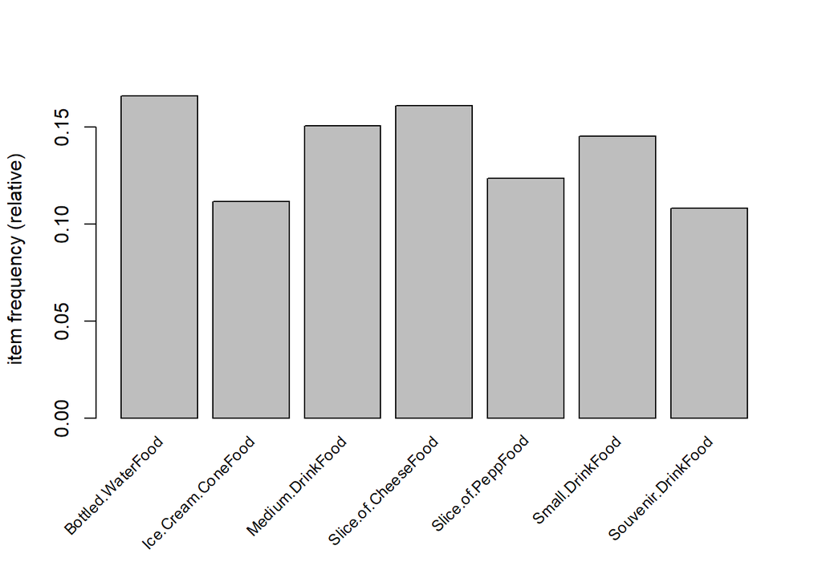

```r
itemFrequencyPlot(TransFood, support = 0.1, cex.names=0.8)
```

Use apriori() algorithm to find all rules (the default association type for apriori()) with a minimum support of 0.3% and a confidence of 0.5.

```r
# Run the apriori algorithm
basket_rules <- apriori(TransFood,parameter = list(sup = 0.003, conf = 0.5,target="rules"))
```

```
## Apriori
##
## Parameter specification:
##  confidence minval smax arem  aval originalSupport maxtime support minlen
##         0.5    0.1    1 none FALSE            TRUE       5   0.003      1
##  maxlen target   ext
##      10  rules FALSE
##
## Algorithmic control:
##  filter tree heap memopt load sort verbose
##     0.1 TRUE TRUE  FALSE TRUE    2    TRUE
##
## Absolute minimum support count: 57
##
## set item appearances ...[0 item(s)] done [0.00s].
## set transactions ...[115 item(s), 19076 transaction(s)] done [0.01s].
## sorting and recoding items ... [74 item(s)] done [0.00s].
## creating transaction tree ... done [0.01s].
## checking subsets of size 1 2 3 4 done [0.01s].
## writing ... [42 rule(s)] done [0.00s].
## creating S4 object  ... done [0.00s].
```

SUmmary of the basket rules

```r
summary(basket_rules)
```

```
## set of 42 rules
##
## rule length distribution (lhs + rhs):sizes
##  2  3  4
## 12 27  3
##
##    Min. 1st Qu.  Median    Mean 3rd Qu.    Max.
##   2.000   2.000   3.000   2.786   3.000   4.000
##
## summary of quality measures:
##     support           confidence          lift            count
##  Min.   :0.003093   Min.   :0.5032   Min.   : 3.125   Min.   : 59.00
##  1st Qu.:0.003683   1st Qu.:0.5944   1st Qu.: 6.307   1st Qu.: 70.25
##  Median :0.004561   Median :0.7586   Median : 8.235   Median : 87.00
##  Mean   :0.006836   Mean   :0.7404   Mean   : 8.929   Mean   :130.40
##  3rd Qu.:0.007496   3rd Qu.:0.8721   3rd Qu.: 9.016   3rd Qu.:143.00
##  Max.   :0.028570   Max.   :1.0000   Max.   :26.179   Max.   :545.00
##
## mining info:
##       data ntransactions support confidence
##  TransFood         19076   0.003        0.5
```

Checking the generated rules

```r
inspect(basket_rules)
```

```
##      lhs                                    rhs                              support confidence      lift count
## [1]  {Small.Pink.LemonadeFood}           => {Chicken.Nugget.BasketFood}  0.003355001  0.5925926 16.034463    64
## [2]  {Grilled.Chicken.SandwichFood}      => {French.Fries.BasketFood}    0.003721954  0.6698113  6.862149    71
## [3]  {FloatFood}                         => {Ice.Cream.ConeFood}         0.007024533  0.7089947  6.355631   134
## [4]  {Side.of.CheeseFood}                => {Cheese.ConeyFood}           0.004665548  0.6846154 25.912149    89
## [5]  {Side.of.CheeseFood}                => {Hot.DogFood}                0.006290627  0.9230769 21.605663   120
## [6]  {BurgerFood}                        => {French.Fries.BasketFood}    0.004613126  0.6616541  6.778579    88
## [7]  {SandwichFood}                      => {French.Fries.BasketFood}    0.007653596  0.6822430  6.989510   146
## [8]  {Hot.Chocolate.Souvenir.RefillFood} => {Hot.Chocolate.SouvenirFood} 0.014992661  0.5596869 13.180972   286
## [9]  {ToppingFood}                       => {Ice.Cream.ConeFood}         0.028569931  0.9981685  8.947868   545
## [10] {Add.CheeseFood}                    => {Soft.Pretzel..3_39Food}     0.019133990  0.6965649  7.601643   365
## [11] {Chicken.TendersFood}               => {French.Fries.BasketFood}    0.017299224  0.7586207  7.771992   330
## [12] {CheeseburgerFood}                  => {French.Fries.BasketFood}    0.016879849  0.7931034  8.125264   322
## [13] {Cheese.ConeyFood,
##       Side.of.CheeseFood}                => {Hot.DogFood}                0.004351017  0.9325843 21.828193    83
## [14] {Hot.DogFood,
##       Side.of.CheeseFood}                => {Cheese.ConeyFood}           0.004351017  0.6916667 26.179034    83
## [15] {Bottled.WaterFood,
##       ToppingFood}                       => {Ice.Cream.ConeFood}         0.004036486  1.0000000  8.964286    77
## [16] {Add.CheeseFood,
##       Bottled.WaterFood}                 => {Soft.Pretzel..3_39Food}     0.003826798  0.8021978  8.754419    73
## [17] {CheeseburgerFood,
##       Chicken.TendersFood}               => {French.Fries.BasketFood}    0.003931642  0.9615385  9.850863    75
## [18] {Chicken.TendersFood,
##       Souvenir.DrinkFood}                => {French.Fries.BasketFood}    0.003197735  0.7922078  8.116088    61
## [19] {Chicken.TendersFood,
##       Krazy.KritterFood}                 => {French.Fries.BasketFood}    0.005661564  0.9557522  9.791584   108
## [20] {Chicken.TendersFood,
##       Slice.of.PeppFood}                 => {French.Fries.BasketFood}    0.003669532  0.9210526  9.436090    70
## [21] {Chicken.TendersFood,
##       Small.DrinkFood}                   => {French.Fries.BasketFood}    0.004822814  0.8214286  8.415452    92
## [22] {Chicken.TendersFood,
##       Medium.DrinkFood}                  => {French.Fries.BasketFood}    0.004141329  0.8144330  8.343783    79
## [23] {Bottled.WaterFood,
##       Chicken.TendersFood}               => {French.Fries.BasketFood}    0.003459845  0.7586207  7.771992    66
## [24] {Chicken.TendersFood,
##       Slice.of.CheeseFood}               => {French.Fries.BasketFood}    0.005399455  0.8728814  8.942580   103
## [25] {CheeseburgerFood,
##       Souvenir.DrinkFood}                => {French.Fries.BasketFood}    0.003250157  0.9117647  9.340936    62
## [26] {CheeseburgerFood,
```

[output cut: 21 more lines]

```
## [37] {Slice.of.PeppFood,
##       Souvenir.DrinkFood}                => {Slice.of.CheeseFood}        0.008125393  0.5032468  3.124979   155
## [38] {Medium.DrinkFood,
##       Slice.of.PeppFood}                 => {Slice.of.CheeseFood}        0.013629692  0.5273834  3.274858   260
## [39] {Bottled.WaterFood,
##       Slice.of.PeppFood}                 => {Slice.of.CheeseFood}        0.010694066  0.5151515  3.198903   204
## [40] {Krazy.KritterFood,
##       Medium.DrinkFood,
##       Slice.of.PeppFood}                 => {Slice.of.CheeseFood}        0.003250157  0.5535714  3.437477    62
## [41] {Medium.DrinkFood,
##       Slice.of.PeppFood,
##       Small.DrinkFood}                   => {Slice.of.CheeseFood}        0.003145313  0.6000000  3.725781    60
## [42] {Medium.DrinkFood,
##       Slice.of.CheeseFood,
##       Small.DrinkFood}                   => {Slice.of.PeppFood}          0.003145313  0.5172414  4.191545    60
```

Basket rules of size greater than 3

```r
inspect(subset(basket_rules, size(basket_rules)>3))
```

```
##     lhs                      rhs                       support confidence     lift count
## [1] {Krazy.KritterFood,
##      Medium.DrinkFood,
##      Slice.of.PeppFood}   => {Slice.of.CheeseFood} 0.003250157  0.5535714 3.437477    62
## [2] {Medium.DrinkFood,
##      Slice.of.PeppFood,
##      Small.DrinkFood}     => {Slice.of.CheeseFood} 0.003145313  0.6000000 3.725781    60
## [3] {Medium.DrinkFood,
##      Slice.of.CheeseFood,
##      Small.DrinkFood}     => {Slice.of.PeppFood}   0.003145313  0.5172414 4.191545    60
```

```r
inspect(subset(basket_rules, lift>5))
```

```
##      lhs                                    rhs                              support confidence      lift count
## [1]  {Small.Pink.LemonadeFood}           => {Chicken.Nugget.BasketFood}  0.003355001  0.5925926 16.034463    64
## [2]  {Grilled.Chicken.SandwichFood}      => {French.Fries.BasketFood}    0.003721954  0.6698113  6.862149    71
## [3]  {FloatFood}                         => {Ice.Cream.ConeFood}         0.007024533  0.7089947  6.355631   134
## [4]  {Side.of.CheeseFood}                => {Cheese.ConeyFood}           0.004665548  0.6846154 25.912149    89
## [5]  {Side.of.CheeseFood}                => {Hot.DogFood}                0.006290627  0.9230769 21.605663   120
## [6]  {BurgerFood}                        => {French.Fries.BasketFood}    0.004613126  0.6616541  6.778579    88
## [7]  {SandwichFood}                      => {French.Fries.BasketFood}    0.007653596  0.6822430  6.989510   146
## [8]  {Hot.Chocolate.Souvenir.RefillFood} => {Hot.Chocolate.SouvenirFood} 0.014992661  0.5596869 13.180972   286
## [9]  {ToppingFood}                       => {Ice.Cream.ConeFood}         0.028569931  0.9981685  8.947868   545
## [10] {Add.CheeseFood}                    => {Soft.Pretzel..3_39Food}     0.019133990  0.6965649  7.601643   365
## [11] {Chicken.TendersFood}               => {French.Fries.BasketFood}    0.017299224  0.7586207  7.771992   330
## [12] {CheeseburgerFood}                  => {French.Fries.BasketFood}    0.016879849  0.7931034  8.125264   322
## [13] {Cheese.ConeyFood,
##       Side.of.CheeseFood}                => {Hot.DogFood}                0.004351017  0.9325843 21.828193    83
## [14] {Hot.DogFood,
##       Side.of.CheeseFood}                => {Cheese.ConeyFood}           0.004351017  0.6916667 26.179034    83
## [15] {Bottled.WaterFood,
##       ToppingFood}                       => {Ice.Cream.ConeFood}         0.004036486  1.0000000  8.964286    77
## [16] {Add.CheeseFood,
##       Bottled.WaterFood}                 => {Soft.Pretzel..3_39Food}     0.003826798  0.8021978  8.754419    73
## [17] {CheeseburgerFood,
##       Chicken.TendersFood}               => {French.Fries.BasketFood}    0.003931642  0.9615385  9.850863    75
## [18] {Chicken.TendersFood,
##       Souvenir.DrinkFood}                => {French.Fries.BasketFood}    0.003197735  0.7922078  8.116088    61
## [19] {Chicken.TendersFood,
##       Krazy.KritterFood}                 => {French.Fries.BasketFood}    0.005661564  0.9557522  9.791584   108
## [20] {Chicken.TendersFood,
##       Slice.of.PeppFood}                 => {French.Fries.BasketFood}    0.003669532  0.9210526  9.436090    70
## [21] {Chicken.TendersFood,
##       Small.DrinkFood}                   => {French.Fries.BasketFood}    0.004822814  0.8214286  8.415452    92
## [22] {Chicken.TendersFood,
##       Medium.DrinkFood}                  => {French.Fries.BasketFood}    0.004141329  0.8144330  8.343783    79
## [23] {Bottled.WaterFood,
##       Chicken.TendersFood}               => {French.Fries.BasketFood}    0.003459845  0.7586207  7.771992    66
## [24] {Chicken.TendersFood,
##       Slice.of.CheeseFood}               => {French.Fries.BasketFood}    0.005399455  0.8728814  8.942580   103
## [25] {CheeseburgerFood,
##       Souvenir.DrinkFood}                => {French.Fries.BasketFood}    0.003250157  0.9117647  9.340936    62
## [26] {CheeseburgerFood,
##       Krazy.KritterFood}                 => {French.Fries.BasketFood}    0.005451877  0.8813559  9.029402   104
## [27] {CheeseburgerFood,
##       Slice.of.PeppFood}                 => {French.Fries.BasketFood}    0.003721954  0.8658537  8.870582    71
## [28] {CheeseburgerFood,
##       Small.DrinkFood}                   => {French.Fries.BasketFood}    0.004141329  0.8315789  8.519441    79
## [29] {CheeseburgerFood,
##       Medium.DrinkFood}                  => {French.Fries.BasketFood}    0.005189767  0.8761062  8.975619    99
## [30] {Bottled.WaterFood,
##       CheeseburgerFood}                  => {French.Fries.BasketFood}    0.003092892  0.7662338  7.849987    59
## [31] {CheeseburgerFood,
##       Slice.of.CheeseFood}               => {French.Fries.BasketFood}    0.005242189  0.8695652  8.908607   100
## [32] {Hot.DogFood,
##       Krazy.KritterFood}                 => {French.Fries.BasketFood}    0.003669532  0.6140351  6.290727    70
```

```r
Hot.DogFood.rhs <- subset(basket_rules, subset = rhs %in% "Hot.DogFood" & lift>5)
inspect(Hot.DogFood.rhs)
```

```
##     lhs                     rhs               support confidence     lift count
## [1] {Side.of.CheeseFood} => {Hot.DogFood} 0.006290627  0.9230769 21.60566   120
## [2] {Cheese.ConeyFood,
##      Side.of.CheeseFood} => {Hot.DogFood} 0.004351017  0.9325843 21.82819    83
```

The numbers we obtain match with the study published by Ben.

### Visualizing the association rules

confidence vs support plot

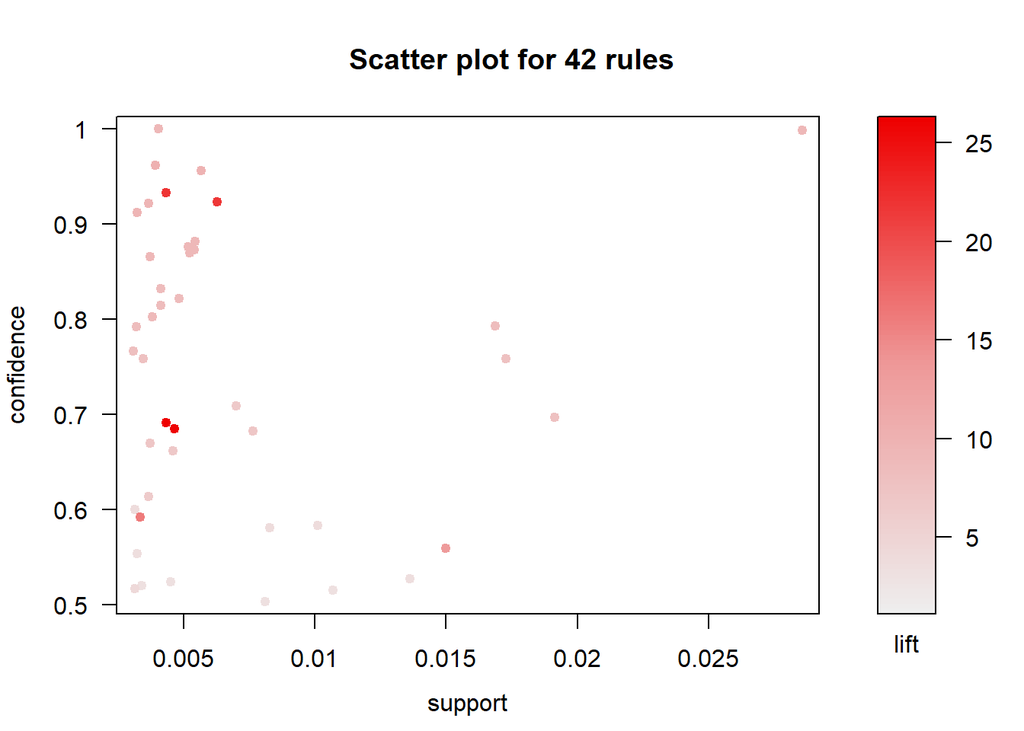

```r
plot(basket_rules)
```

Graph-based visualization can be used for very small sets of rules. The vertices are represented by items for the 10 rules with highest lift:

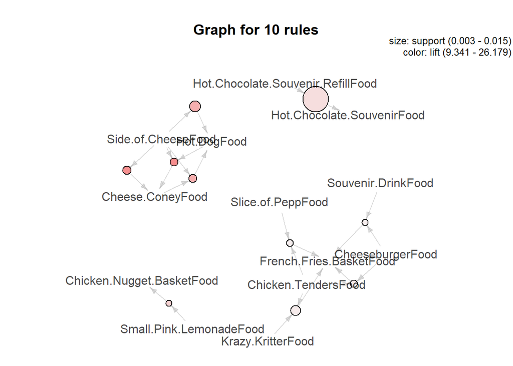

```r
plot(head(sort(basket_rules, by="lift"), 10), method = "graph")
```

Plot of clustered association rules and itemsets:

[figure not shown]

```r
plot(basket_rules, method="grouped")
```